# Métodos Cuantitativos en Ecología - MCE5

EXAMEN FINAL - 2023I

Vela Aulestia

11 de Julio de 2023

Los contenidos de esta evaluación corresponden a los temas:

- GLM y GAM
- Introducción a estadística Bayesiana
- Series de tiempo
- Análisis espacial

Ustedes estan utilizando un archivo tipo R Markdown (`.Rmd`). Las instruciones son **[1 PUNTO]**:

- Bifurquen el repositorio en GitHub y clonen en su computador usando un proyecto con control de la versión de RStudio.
- Arriba, donde dice “author”, deben llenar sus nombres.
- **Todo resultado debe ir con su explicación y/o discusión, caso contrario no se calificará.**
- **NO IMPRIMA los datos o tablas completas**, reporte únicamente figuras o tablas resumen. Si tiene varias figuras use la función `ggarrange` de la librería `ggpubr`.
- Al final de este examen deben utilizar el comando “Knit” para generar un archivo HTML.

## PREGUNTA 1: GLM, GAM y Regresión Bayesiana [3 PUNTOS]

```r
library(ggpubr)
ggarrange
```

[output not shown]

En el archivo `"glm.xlsx"` tiene tres datos:

- aedes: insecticidas utilizados para controlar el número de mosquitos en un experimento. Cada vez que se repite la aplicación del insecticida parece disminuir la cantidad de zancudos vivos.
- leishmania: en una infección con leishmania cuando se analiza el tejido qué sucede con la concentración de algunas células y si están o no afectadas.
- disease: cómo la edad afecta a diferentes características dicotómicas.

### Realice los siguientes análisis:

## Aedes: GLM

```r
library(readxl)
aedes <- read_excel("aedes.xlsx")
View(aedes)
```

### Análisis exploratorio

```r
library(MASS); library(ggplot2)
head(aedes, 2)
```

```
## # A tibble: 2 × 3
##   agrochem repetition aedes
##   <chr>         <dbl> <dbl>
## 1 A                 1  2370
## 2 B                 1  1282
```

```r
summary(aedes) # ESTADÍSTICA DESCRIPTIVA
```

```
##    agrochem           repetition      aedes
##  Length:30          Min.   :1.0   Min.   :  44.0
##  Class :character   1st Qu.:2.0   1st Qu.: 136.5
##  Mode  :character   Median :3.5   Median : 523.5
##                     Mean   :3.5   Mean   : 865.4
##                     3rd Qu.:5.0   3rd Qu.:1217.8
##                     Max.   :6.0   Max.   :3020.0
```

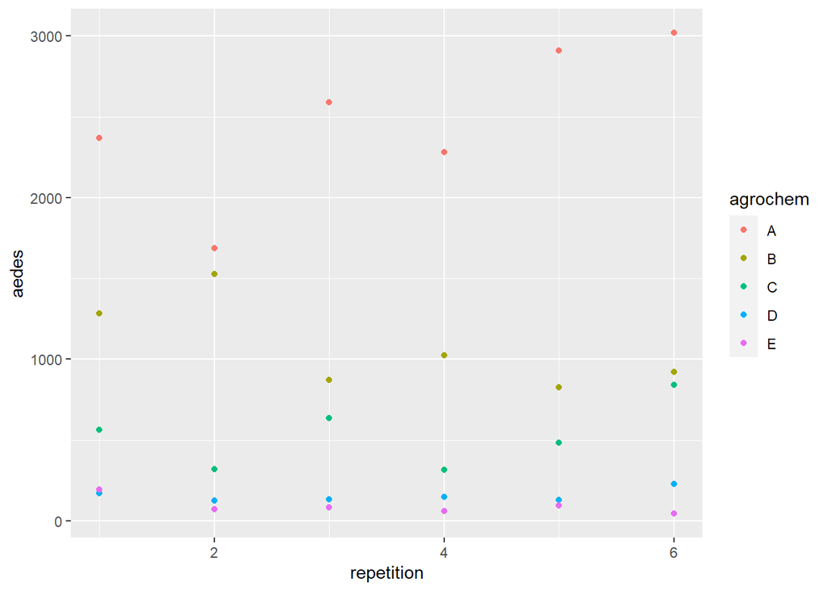

```r
# VISUALIZACIÓN PRELIMINAR
library(ggplot2)
ggplot(data = aedes, aes(x = repetition, y = aedes,
                          col = agrochem)) +
  geom_point()
```

#### Planteamiento de hipótesis.

Por lo que se plantea la siguiente hipotesis:

$H_0$: La repeticiones de aplicación de agroquímicos no tiene un efecto sobre la población de zancudos

$H_1$: La repeticiones de aplicación de agroquímicos disminuye la población de zancudos

#### Análisis de regresión

```r
h01 <- lm(repetition ~ aedes, data = aedes)
summary(h01)
```

```
##
## Call:
## lm(formula = repetition ~ aedes, data = aedes)
##
## Residuals:
##      Min       1Q   Median       3Q      Max
## -2.62154 -1.45211 -0.02562  1.52386  2.56635
##
## Coefficients:
##              Estimate Std. Error t value Pr(>|t|)
## (Intercept) 3.430e+00  4.447e-01   7.714 2.11e-08 ***
## aedes       8.078e-05  3.538e-04   0.228    0.821
## ---
## Signif. codes:  0 '***' 0.001 '**' 0.01 '*' 0.05 '.' 0.1 ' ' 1
##
## Residual standard error: 1.766 on 28 degrees of freedom
## Multiple R-squared:  0.001858,   Adjusted R-squared:  -0.03379
## F-statistic: 0.05212 on 1 and 28 DF,  p-value: 0.8211
```

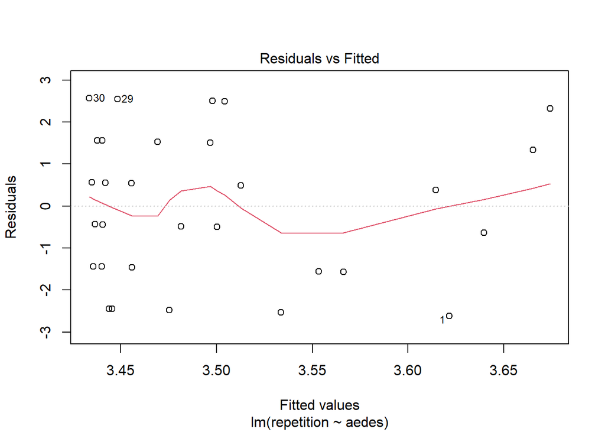

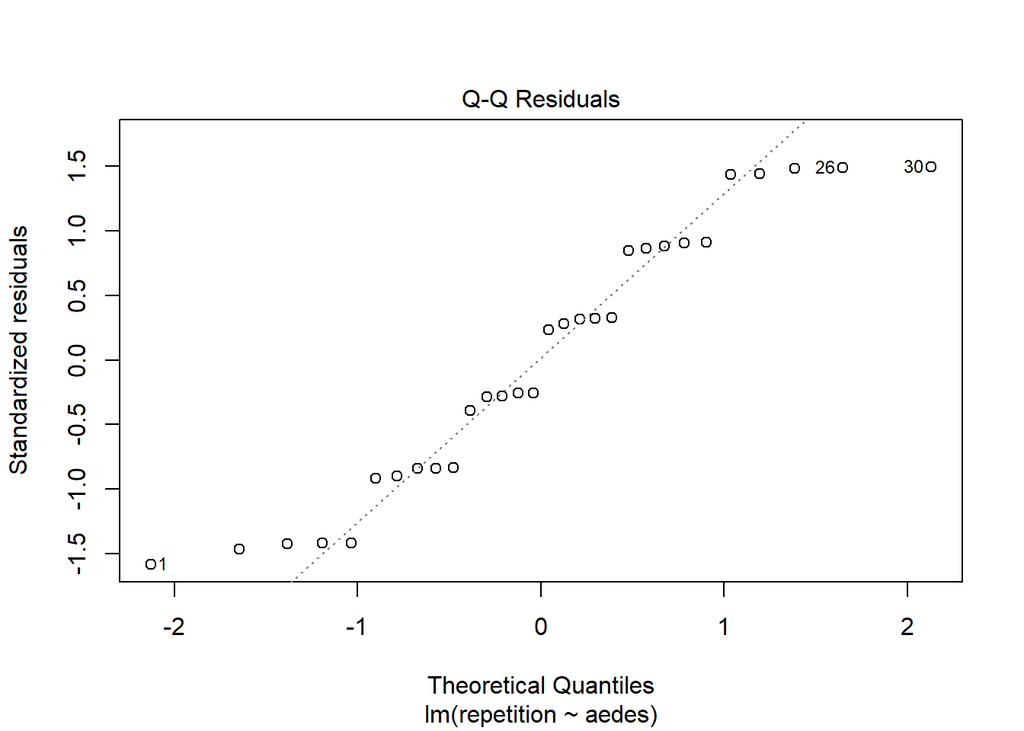

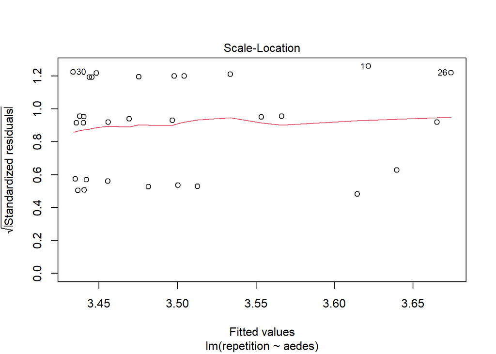

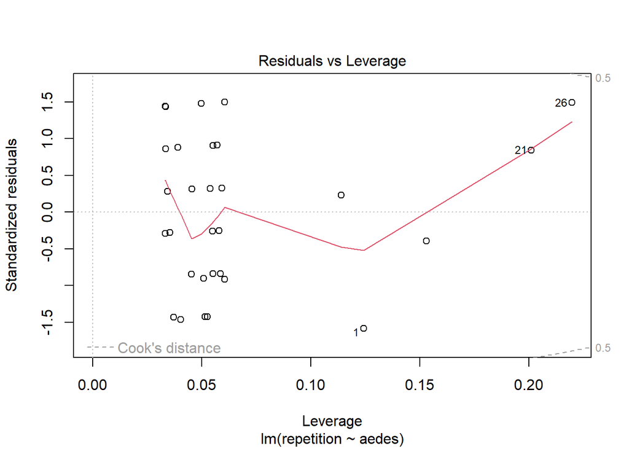

```r
plot(h01)
```

#### Planteamiento del modelo.

[figure not shown]

```r
boxplot(aedes$repetition ~ aedes$aedes, ylab = "Población de Zancudos muertos", xlab = "Repetición", fill = aedes$agrochem)
```

[figure not shown]

```r
plot(aedes$repetition, aedes$aedes, ylab = "Repeticion de Agroquimicos", xlab = "Población de Zancudos")
reg <- lm(aedes$repetition ~ aedes$aedes)
abline(reg)
```

La regresión lineal es constante por lo que no indica mayor información al análisis del efecto de los agroquímicos en la población de los zancudos

### Familia Possion:

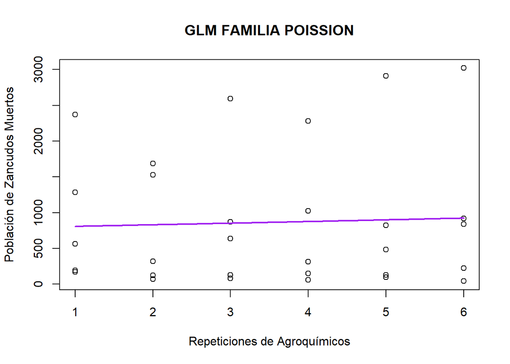

```r
glm1<- glm(aedes ~ repetition, data = aedes, family = poisson)
# Gráfico de dispersión con línea de ajuste
plot(aedes$repetition, aedes$aedes, main = "GLM FAMILIA POISSION", xlab = "Repeticiones de Agroquímicos", ylab = "Población de Zancudos Muertos")
x_seq <- seq(min(aedes$repetition), max(aedes$repetition), length.out = 100)
pred_counts <- predict(glm1, newdata = data.frame(repetition = x_seq), type = "response")
lines(x_seq, pred_counts, col = "purple", lwd = 2)
```

### Validación del Modelo

```r
print(AIC(reg))
```

```
## [1] 123.1938
```

```r
print(glm1$aic)
```

```
## [1] 26818.86
```

El AIC para el modelo de regresión es menor que el AIC del modelo glm perteneciente a la familia possion. Por lo que, el modelo lineal de rgresión está mejor ajustado a los valores e indica que es el que mejor describe los datos y mejor puede predecir su comportamiento

## Disease: GLMs binomiales

```r
library(readxl)
disease <- read_excel("disease.xlsx")
View(disease)
```

### Análisis exploratorio

```r
library(MASS); library(ggplot2)
head(disease, 2)
```

```
## # A tibble: 2 × 5
##   native gender treatment recover   age
##    <dbl>  <dbl>     <dbl>   <dbl> <dbl>
## 1      0      0         0       0    33
## 2      0      0         0       0    35
```

```r
summary(disease) # ESTADÍSTICA DESCRIPTIVA
```

```
##      native           gender         treatment        recover
##  Min.   :0.0000   Min.   :0.0000   Min.   :0.000   Min.   :0.0000
##  1st Qu.:0.0000   1st Qu.:0.0000   1st Qu.:0.000   1st Qu.:0.0000
##  Median :0.0000   Median :0.0000   Median :0.000   Median :0.0000
##  Mean   :0.2449   Mean   :0.3673   Mean   :0.398   Mean   :0.3163
##  3rd Qu.:0.0000   3rd Qu.:1.0000   3rd Qu.:1.000   3rd Qu.:1.0000
##  Max.   :1.0000   Max.   :1.0000   Max.   :1.000   Max.   :1.0000
##       age
##  Min.   : 1.0
##  1st Qu.: 9.5
##  Median :20.5
##  Mean   :25.2
##  3rd Qu.:35.0
##  Max.   :74.0
```

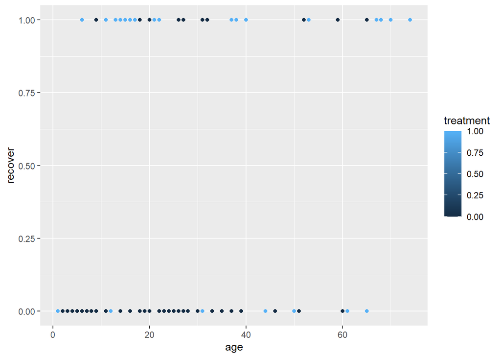

```r
# VISUALIZACIÓN PRELIMINAR
library(ggplot2)
ggplot(data = disease, aes(x = age, y = recover,
                          col = treatment)) +
  geom_point()
```

### Planteamiento de Hipotesis:

Por lo que se plantea lo siguiente:

$H_0$: La edad no influe en la recuperación de los pacientes.

$H_1:$ La edad tiene un efecto en la recuperación de los pacientes

### Análisis de Regresión:

```r
h02 <- lm(age ~ recover, data = disease)
summary(h02)
```

```
##
## Call:
## lm(formula = age ~ recover, data = disease)
##
## Residuals:
##     Min      1Q  Median      3Q     Max
## -26.774 -14.756  -3.701   9.299  43.299
##
## Coefficients:
##             Estimate Std. Error t value Pr(>|t|)
## (Intercept)   21.701      2.195   9.886 2.62e-16 ***
## recover       11.073      3.903   2.837  0.00556 **
## ---
## Signif. codes:  0 '***' 0.001 '**' 0.01 '*' 0.05 '.' 0.1 ' ' 1
##
## Residual standard error: 17.97 on 96 degrees of freedom
## Multiple R-squared:  0.07735,    Adjusted R-squared:  0.06774
## F-statistic: 8.048 on 1 and 96 DF,  p-value: 0.005557
```

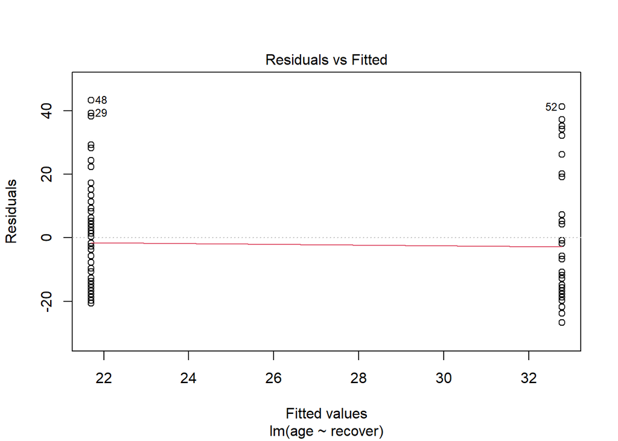

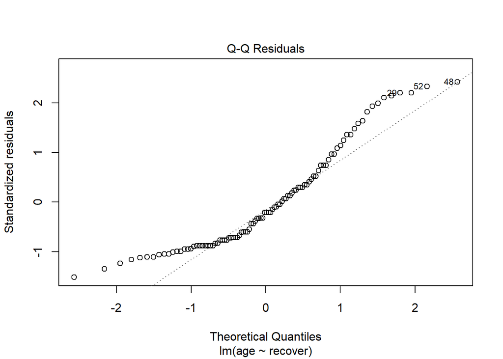

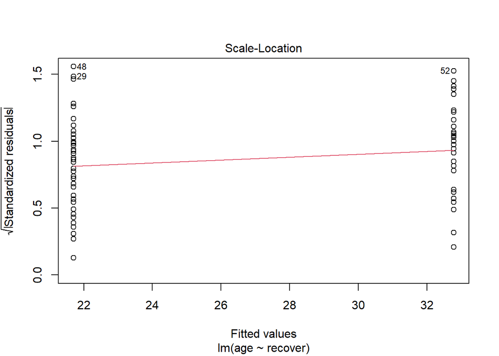

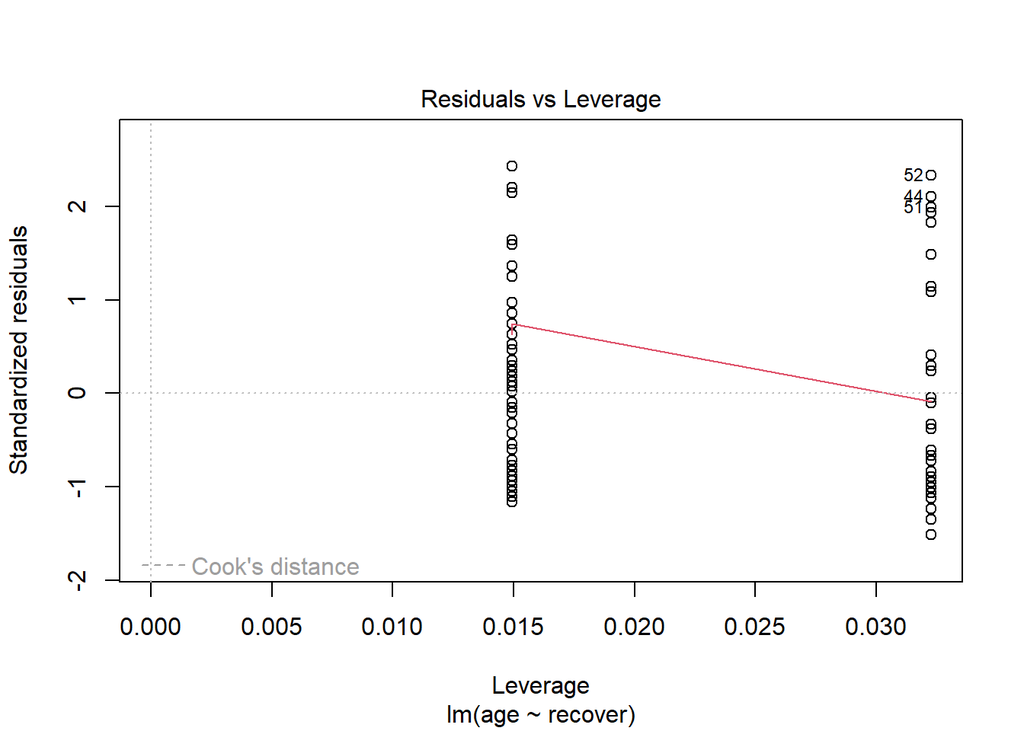

```r
plot(h02)
```

### Plantamiento de Modelo

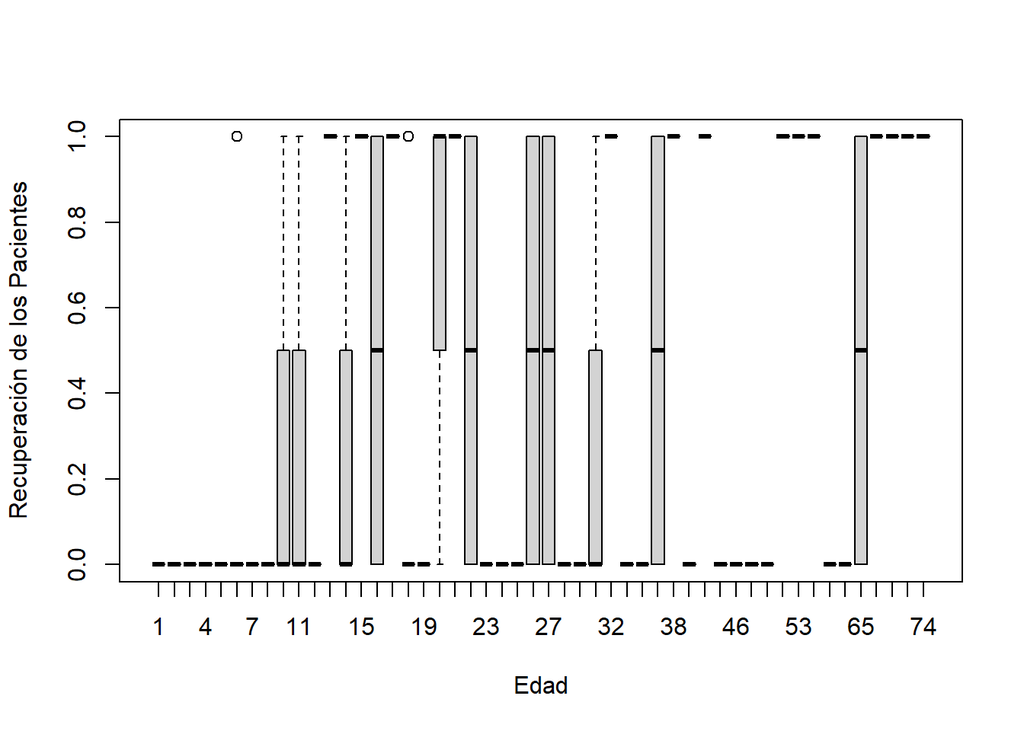

```r
boxplot(disease$recover ~ disease$age, ylab = "Recuperación de los Pacientes", xlab = "Edad", fill = disease$treatment)
```

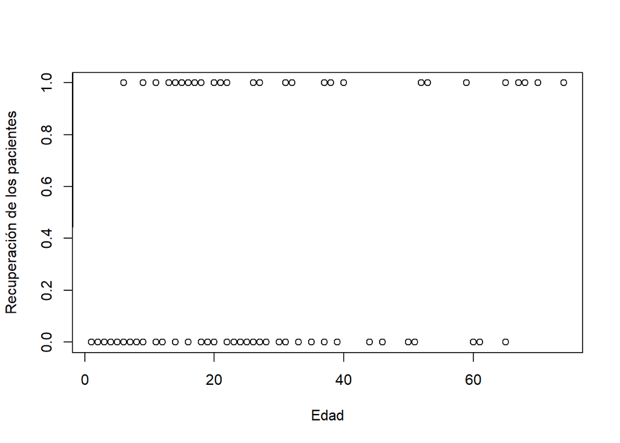

```r
plot(disease$age, disease$recover, ylab = "Recuperación de los pacientes", xlab = "Edad")
reg1 <- lm(disease$age ~ disease$recover)
abline(reg1)
```

### Familia Binomial:

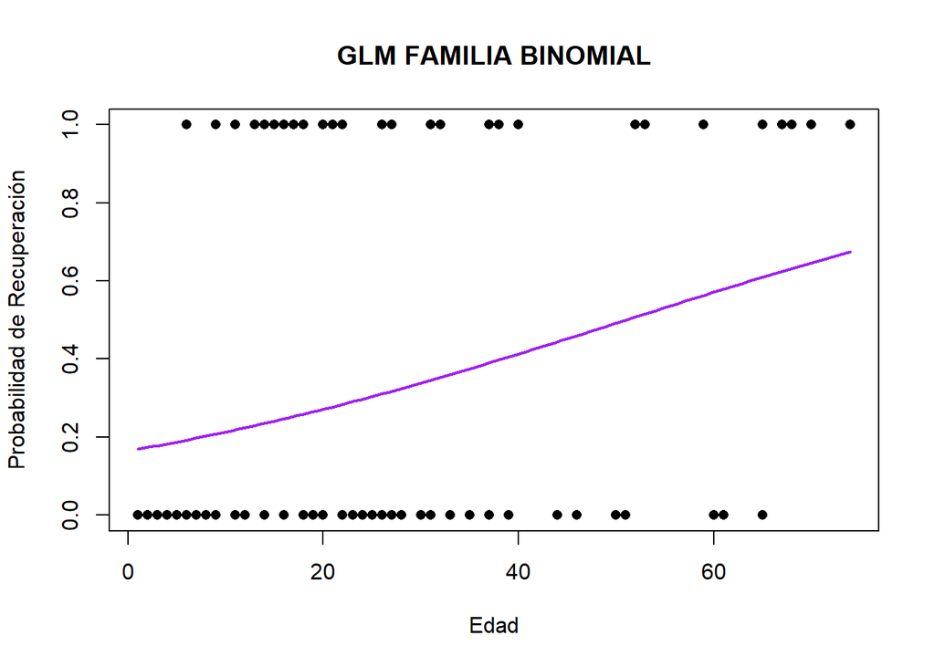

```r
glm2 <- glm(recover ~ age, data = disease, family = binomial())
plot(disease$age, disease$recover, main = "GLM FAMILIA BINOMIAL", xlab = "Edad", ylab = "Probabilidad de Recuperación", pch = 16)
x_seq <- seq(min(disease$age), max(disease$age), length.out = 100)
pred_probs <- predict(glm2, newdata = data.frame(age = x_seq), type = "response")
lines(x_seq, pred_probs, col = "purple", lwd = 2)
```

### Validación del Modelo:

```r
print(AIC(reg1))
```

```
## [1] 848.2615
```

```r
print(glm2$aic)
```

```
## [1] 118.9126
```

Se comprueba que el modelos que mejor se ajusta a los datos y los describe es el modelo GLM perteneciente a la familia binomial al tener un valor de 118.91 en el AIC.

## Leishmania: glm bayesiano

### Análisis exploratorio

```r
library(readxl)
leishmania <- read_excel("leishmania.xlsx")
View(leishmania)
library(MASS); library(ggplot2)
head(leishmania, 2)
```

```
## # A tibble: 2 × 7
##   recupera percent_blast percent_affect percent_leuco periferia_leuco
##      <dbl>         <dbl>          <dbl>         <dbl>           <dbl>
## 1        1           0.8           0.83          0.66             1.9
## 2        1           0.9           0.36          0.32             1.4
## # ℹ 2 more variables: periferia_blast <dbl>, temperature <dbl>
```

```r
summary(leishmania) # ESTADÍSTICA DESCRIPTIVA
```

```
##     recupera      percent_blast    percent_affect   percent_leuco
##  Min.   :0.0000   Min.   :0.2000   Min.   :0.3200   Min.   :0.0800
##  1st Qu.:0.0000   1st Qu.:0.8250   1st Qu.:0.4300   1st Qu.:0.3350
##  Median :0.0000   Median :0.9500   Median :0.6500   Median :0.6300
##  Mean   :0.3333   Mean   :0.8815   Mean   :0.6352   Mean   :0.5707
##  3rd Qu.:1.0000   3rd Qu.:1.0000   3rd Qu.:0.8350   3rd Qu.:0.7400
##  Max.   :1.0000   Max.   :1.0000   Max.   :0.9700   Max.   :0.9200
##  periferia_leuco periferia_blast   temperature
##  Min.   :0.400   Min.   :0.0000   Min.   :0.9800
##  1st Qu.:0.650   1st Qu.:0.2300   1st Qu.:0.9900
##  Median :0.900   Median :0.5200   Median :0.9900
##  Mean   :1.004   Mean   :0.6885   Mean   :0.9974
##  3rd Qu.:1.250   3rd Qu.:1.0600   3rd Qu.:1.0050
##  Max.   :1.900   Max.   :2.0600   Max.   :1.0400
```

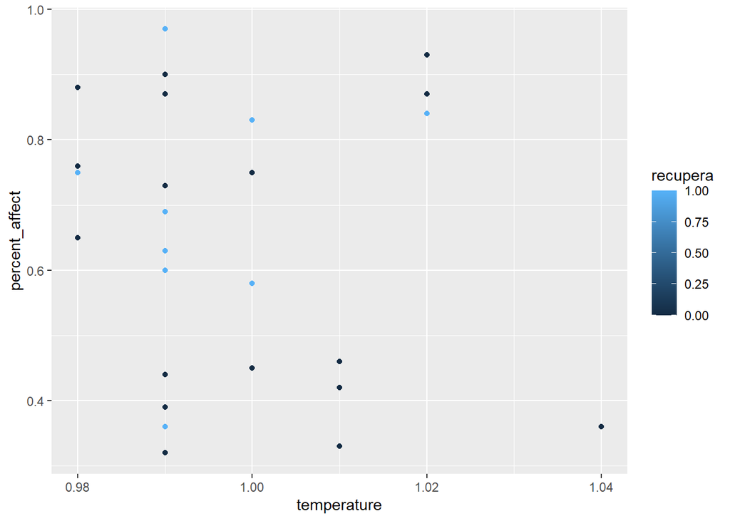

```r
# VISUALIZACIÓN PRELIMINAR
library(ggplot2)
ggplot(data = leishmania, aes(x = temperature, y = percent_affect,
                          col = recupera)) +
  geom_point()
```

### Plantamiento de Hipotesis:

Por lo que se palneta lo siguiente:

$H_0:$ La temperatura no influye en los tejidos.

$H_1:$ La temperatura afecta en los tejidos, por lo que aumenta los tejidos dañados.

### Análisis de Regresión:

```r
h03 <- lm(temperature ~ percent_affect, data = leishmania)
summary(h03)
```

```
##
## Call:
## lm(formula = temperature ~ percent_affect, data = leishmania)
##
## Residuals:
##       Min        1Q    Median        3Q       Max
## -0.017284 -0.009453 -0.005449  0.007132  0.040297
##
## Coefficients:
##                 Estimate Std. Error t value Pr(>|t|)
## (Intercept)     1.002706   0.009203 108.954   <2e-16 ***
## percent_affect -0.008342   0.013756  -0.606     0.55
## ---
## Signif. codes:  0 '***' 0.001 '**' 0.01 '*' 0.05 '.' 0.1 ' ' 1
##
## Residual standard error: 0.01501 on 25 degrees of freedom
## Multiple R-squared:  0.0145, Adjusted R-squared:  -0.02493
## F-statistic: 0.3677 on 1 and 25 DF,  p-value: 0.5497
```

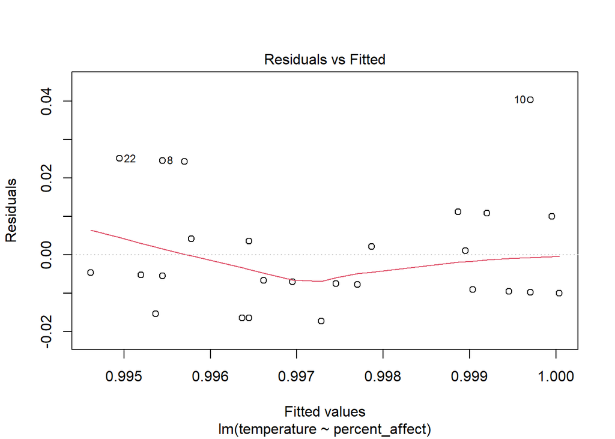

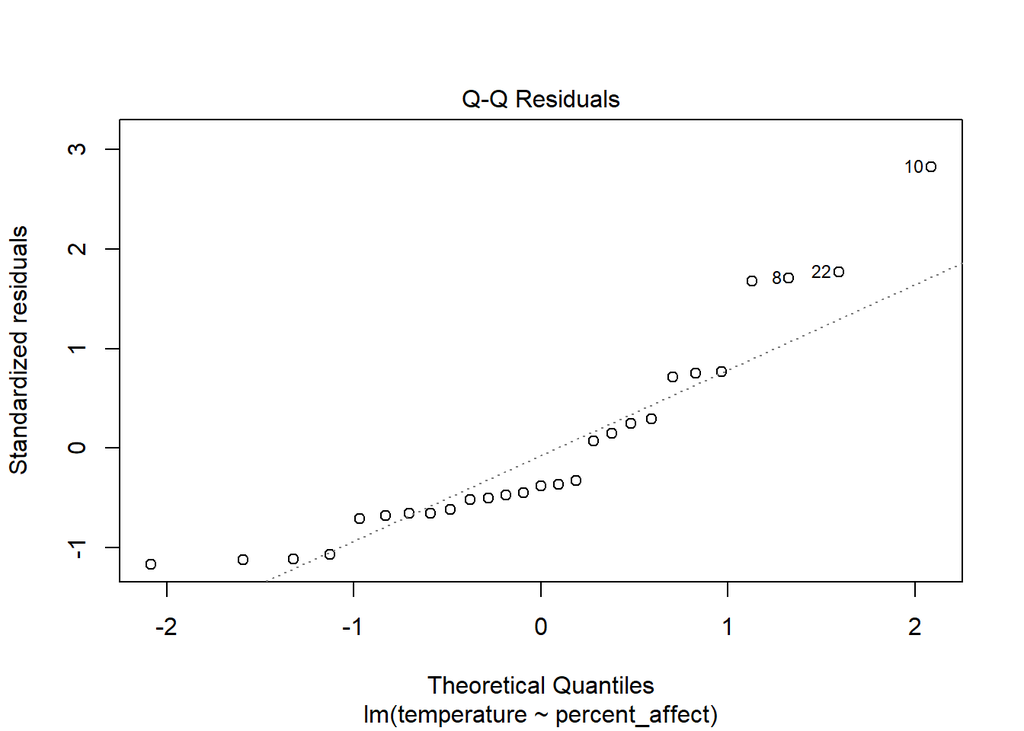

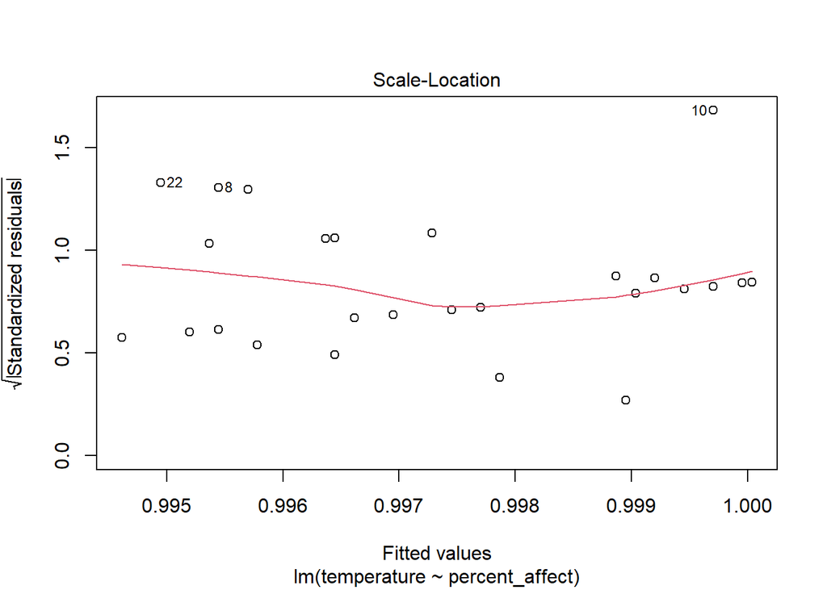

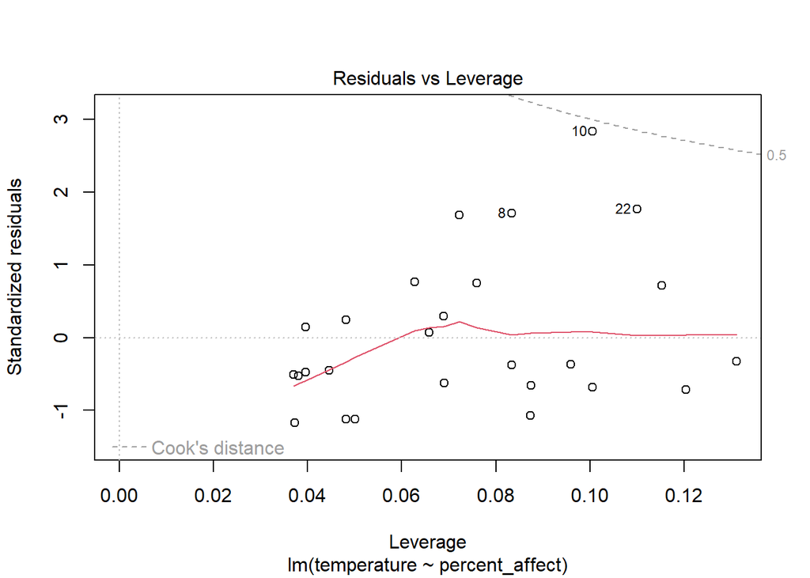

```r
plot(h03)
```

### Planteamiento del Modelo:

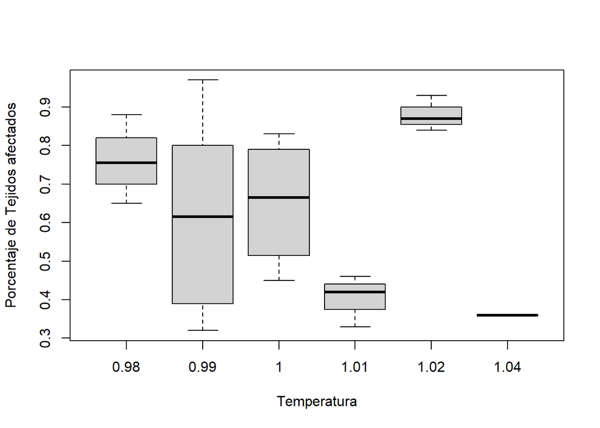

```r
boxplot(leishmania$percent_affect ~ leishmania$temperature, ylab = "Porcentaje de Tejidos afectados", xlab = "Temperatura", fill = disease$treatment)
```

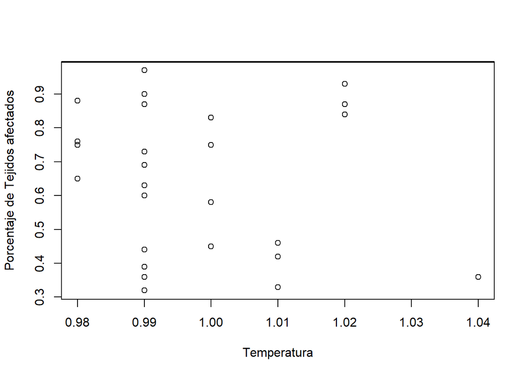

```r
plot(leishmania$temperature, leishmania$percent_affect, ylab = "Porcentaje de Tejidos afectados", xlab = "Temperatura")
reg2 <- lm(leishmania$temperature ~ leishmania$percent_affect)
abline(reg2)
```

Los datos nos parecen seguir un comportamiento en especifico, por lo que no se puede aseverar nada.

### Estadística Bayesiana

```r
library(rstan)
library(rstanarm)
library(rstantools)
data_list <- data.frame(percent_affect = leishmania$percent_affect, temperature = leishmania$temperature)
model_bayesiano <- stan_glm(percent_affect ~ temperature, data = data_list, family = gaussian())
```

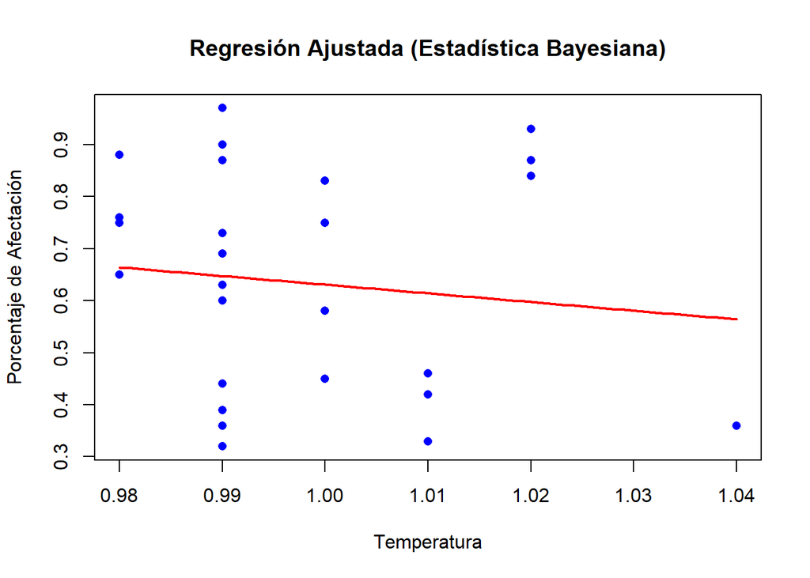

```r
new_data <- data.frame(temperature = seq(min(leishmania$temperature), max(leishmania$temperature), length.out = 100))
predicted_values <- predict(model_bayesiano, newdata = new_data, type = "response")
plot(leishmania$temperature, leishmania$percent_affect,
     main = "Regresión Ajustada (Estadística Bayesiana)",
     xlab = "Temperatura", ylab = "Porcentaje de Afectación",
     col = "blue", pch = 16)
lines(new_data$temperature, predicted_values, col = "red", lwd = 2)
```

### Validación del Modelo

```r
print(AIC(reg2))
```

```
## [1] -146.1884
```

```r
print(model_bayesiano$aic)
```

[output not shown]

## **PREGUNTA 2: Series de tiempo [3 PUNTOS]**

En el archivo `"ts.xlsx"` tiene tres datos:

- quakes: cantidad de eventos de terremotos por cada año.
- hepatitis: casos de hepatitis por mes entre 2010 y 2017 (acomodar la tabla si es necesario)
- wildfire: cantidad de eventos de incendios forestales por mes entre 2003 y 2017.

Realizar los siguientes análisis y respectivas interpretaciones:

1. Análisis exploratorio: autocorrelación y descomposición, análisis estacional.
2. ARIMA, SARIMA, ETS, NNAR
3. Validez de los modelos.
4. Predicción a 20 años o a 24 meses según corresponda.

## **PREGUNTA 3: Análisis espacial de especies [3 PUNTOS]**

Seleccione una especie de planta y una especie de animal; asimismo, dos tipos de modelos de predicción (glm, gam, rf, ann, otro):

- Mosquito: *Aedes aegypti*
- Puma: *Puma concolor*
- Coati: *Nasua nasua*
- Tapir: *Tapirus terrestris*
- Jaguar: *Panthera onca*
- Palma de cera: *Ceroxylon quindiuense*
- Ceibo: *Ceiba pentandra*
- Pasiflora: *Passiflora edulis*
- Chirimoya: *Anona cherimola*

### TAPIR

#### Carga de datos y Selección del Aerea de Estudio

```r
require(pacman)
pacman::p_load(rnaturalearthdata, extrafont, showtext, rnaturalearth, cptcity,
               SSDM, ggspatial, raster, terra, rgbif, tidyverse, sf, sp,
               geodata, glue, ggpubr)

g = gc(reset=T)
rm(list=ls())
options(scipen = 999, warn = -1)
```

```r
sps = "Tapirus terrestris"
occr = occ_data(scientificName = sps, limit = 10e5, hasCoordinate = T,
                hasGeospatialIssue = F)
occr = occr[[2]]
unique(occr$country) %>%  sort()
```

```
##  [1] "Argentina"                          "Bolivia (Plurinational State of)"
##  [3] "Brazil"                             "Colombia"
##  [5] "Ecuador"                            "French Guiana"
##  [7] "Guyana"                             "Paraguay"
##  [9] "Peru"                               "Suriname"
## [11] "United States of America"           "Venezuela (Bolivarian Republic of)"
```

```r
occr = occr %>%  dplyr::filter(country == "Ecuador")
```

#### Contstrucción del Modelo con GLM

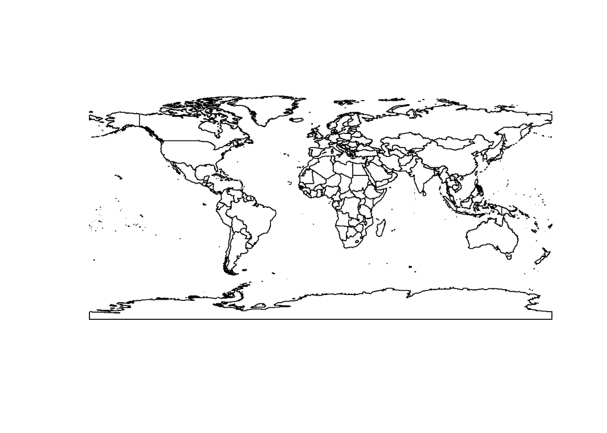

```r
wrld = ne_countries(returnclass = "sf", scale = 50)
ecu1 = geodata::gadm(country = "ECU", level = 1, path = "tmpr")

plot(st_geometry(wrld))
```

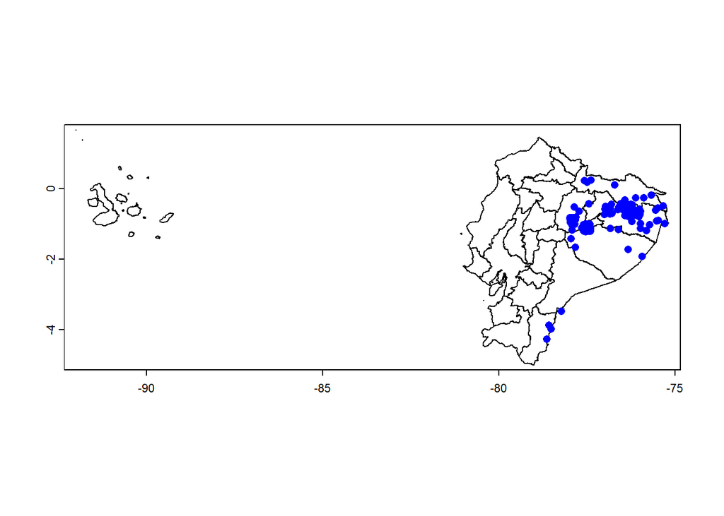

```r
plot(ecu1)
points(occr$decimalLongitude, occr$decimalLatitude, pch = 16, col = "blue")
```

```r
bioc = geodata::worldclim_country(country = "ECU", var = "bioc", path = "tmpr")
bioc = terra::crop(bioc, ecu1) %>% terra::mask(., ecu1)
names(bioc) = glue("bioc{1:19}")


occr = occr %>%  dplyr::select(x = decimalLongitude, y = decimalLatitude)
vles = terra::extract(bioc, occr[,c("x", "y")])
occr = cbind(occr[,c("x", "y")], vles[,-1])
occr = as_tibble(occr)
occr = mutate(occr, pb = 1)


cell = terra::extract(bioc[[1]], occr[,1:2], cells=T)$cell
duplicated(cell)
```

[output not shown]

```r
mask = bioc[[1]]*0
mask[cell] = NA
back = terra::as.data.frame(mask, xy =T) %>% as_tibble()
back = sample_n(back, size = nrow(occr)*2, replace = FALSE)
colnames(back)[3] = "pb"
back = mutate(back, pb = 0)
back = cbind(back, terra::extract(bioc, back[,c(1,2)])[,-1])
back = as_tibble(back)
```

#### UNION DATOS CLIMATICOS Y DISTRIBUCIÓN

```r
tble = rbind(occr, back)

# GLM Model
bioc = stack(bioc)
tble = as.data.frame(tble)

srdf = modelling(algorithm = "GLM", Env = bioc, Occurrences = tble, Pcol = "pb",
                 Xcol = "x", cv.parm = c(0.75, 0.25),
                 Ycol = "y", metric = "TSS", select.metric = "AUC")
```

```
## Data check ...
##    done.
##
## Model evaluation...
##    done.
##
## Model projection...
##    done.
##
## Model axes contribution evaluation...
##    done.
```

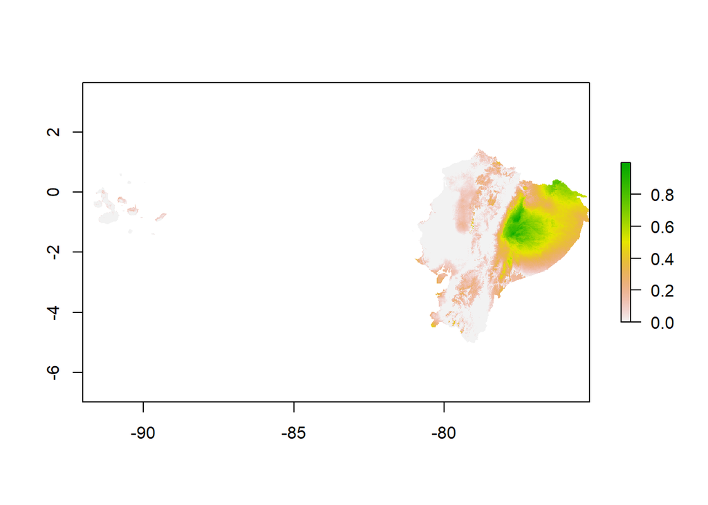

```r
plot(srdf@projection)
```

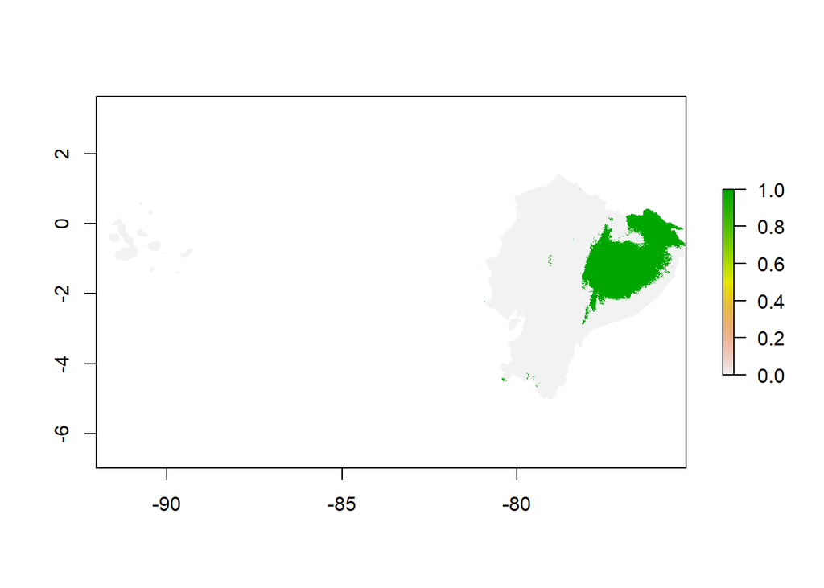

```r
plot(srdf@binary)
```

```r
srdf@parameters
```

```
##                        data metric      cv cv.param axes.metric
## 1 presence/absence data set    TSS holdout   |0.7|2     Pearson
```

```r
srdf@name
```

```
## [1] "GLM.SDM"
```

```r
srdf@variable.importance
```

```
##                     bioc1    bioc2    bioc3       bioc4     bioc5     bioc6
## Axes.evaluation 0.3714847 2.409777 1.601427 0.002142219 0.5074253 0.5074204
##                     bioc7     bioc8    bioc9     bioc10    bioc11   bioc12
## Axes.evaluation 0.5074281 0.2220552 10.75556 0.02124292 0.3957937 27.83487
##                   bioc13    bioc14   bioc15   bioc16  bioc17    bioc18   bioc19
## Axes.evaluation 4.154831 0.6973114 28.58902 3.469552 8.03345 0.3662483 9.552961
```

```r
as.numeric(srdf@variable.importance) %>% sum()
```

```
## [1] 100
```

```r
rstr = srdf@projection
rstr = terra::rast(rstr)
rslt = terra::as.data.frame(rstr, xy = T) %>%  as_tibble()

# Built the map
gmap = ggplot() +
  geom_tile(data = rslt, aes(x = x, y = y, fill = Projection)) +
  scale_fill_gradientn(colors = cpt(pal = "mpl_inferno", n=10, rev = TRUE)) +
  geom_sf(data = wrld, fill = NA, col = "grey40", lwd=0.1) +
  geom_sf(data = st_as_sf(ecu1), fill = NA, col = "grey40", lwd=0.3) +
  coord_sf(xlim = ext(ecu1)[1:2], ylim = ext(ecu1)[3:4]) +
  labs(x = "Longitud", y = "Latitud", fill = "Puntaje de Idoneidad") +
  ggtitle(label = "Idoneidad para Tapir. en Ecuador", subtitle = "Modelo GLM") +
  theme_bw() +
  theme(text = element_text(family="georg", color = "grey50"),
        legend.position = "bottom",
        plot.title = element_text(hjust = 0.5, face = "bold", color ="grey30"),
        plot.subtitle = element_text(hjust = 0.5, face = "bold", color ="grey30"),
        panel.border = element_rect(color = "grey80") ) +
  guides(fill = guide_legend(
    direction = "horizontal",
    keyheight = unit(1.15, units = "mm"), keywidth = unit(1.15, units = "mm"),
    title.position = "top", title.hjust = 0.5, label.hjust = 0.5,
    nrow = 1, byrow = T, reverse = F, label.position = "bottom")) +
  annotation_scale(location="bl", width_hint =0.5, text_family = "georg",
                   text_col = "grey60", text_cex = 0.7 ) +
  annotation_north_arrow(
    location= "tr", which_north = "true",
    pad_x = unit(0.1, "in"), pad_y = unit(0.2, "in"),
    style = north_arrow_fancy_orienteering(text_family = "georg", text_col = "grey40"))
```

Mayor indiviudos número de individuos en la zona amazónica espcielamente en la provincia de Napo y Pastaza. Su idoneidad de habitat es de 0.8 respecto a las dos provincias. La mayor distribución de 1 que representa el 100 se en las pronvinicias del norte de la Amazonía como Napo, Pastaza, Sucumbíos y Orellana.

#### MODELO GAM

```r
# GLM Model
bioc = stack(bioc)
tble = as.data.frame(tble)

srdf = modelling(algorithm = "GAM", Env = bioc, Occurrences = tble, Pcol = "pb",
                 Xcol = "x", cv.parm = c(0.75, 0.25),
                 Ycol = "y", metric = "TSS", select.metric = "AUC")
```

```
## Data check ...
##    done.
##
## Model evaluation...
##    done.
##
## Model projection...
##    done.
##
## Model axes contribution evaluation...
##    done.
```

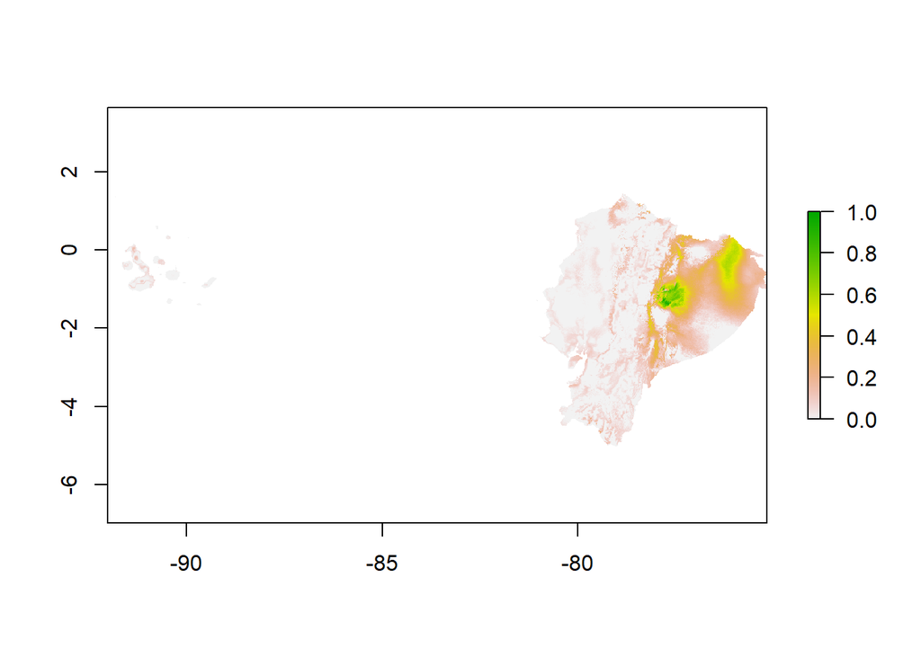

```r
plot(srdf@projection)
```

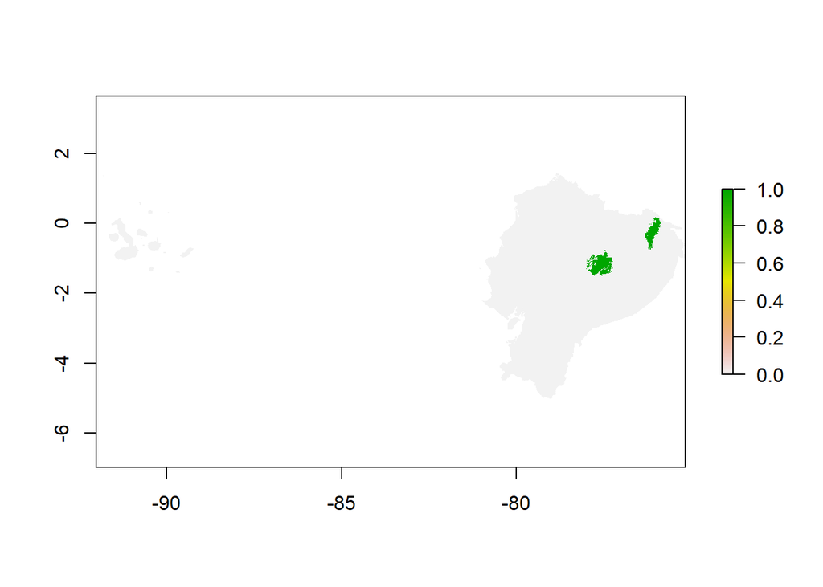

```r
plot(srdf@binary)
```

```r
srdf@parameters
```

```
##                        data metric      cv cv.param axes.metric
## 1 presence/absence data set    TSS holdout   |0.7|2     Pearson
```

```r
srdf@name
```

```
## [1] "GAM.SDM"
```

```r
srdf@variable.importance
```

```
##                     bioc1    bioc2      bioc3     bioc4               bioc5
## Axes.evaluation 0.6937707 3.312753 0.05874715 0.1610255 0.00000000001157821
##                      bioc6     bioc7       bioc8     bioc9     bioc10    bioc11
## Axes.evaluation 0.03905359 0.7529634 0.008703994 0.3175898 0.05711639 0.1088595
##                   bioc12   bioc13   bioc14     bioc15   bioc16  bioc17
## Axes.evaluation 21.06584 1.470008 25.80535 0.01771018 1.063973 33.2933
##                    bioc18  bioc19
## Axes.evaluation 0.3911389 11.3821
```

```r
as.numeric(srdf@variable.importance) %>% sum()
```

```
## [1] 100
```

```r
rstr = srdf@projection
rstr = terra::rast(rstr)
rslt = terra::as.data.frame(rstr, xy = T) %>%  as_tibble()

# Built the map
gmap1 = ggplot() +
  geom_tile(data = rslt, aes(x = x, y = y, fill = Projection)) +
  scale_fill_gradientn(colors = cpt(pal = "mpl_inferno", n=10, rev = TRUE)) +
  geom_sf(data = wrld, fill = NA, col = "grey40", lwd=0.1) +
  geom_sf(data = st_as_sf(ecu1), fill = NA, col = "grey40", lwd=0.3) +
  coord_sf(xlim = ext(ecu1)[1:2], ylim = ext(ecu1)[3:4]) +
  labs(x = "Longitud", y = "Latitud", fill = "Puntaje de Idoneidad") +
  ggtitle(label = "Idoneidad para el Tapir sp. en Ecuador", subtitle = "Modelo GAM") +
  theme_bw() +
  theme(text = element_text(family="georg", color = "grey50"),
        legend.position = "bottom",
        plot.title = element_text(hjust = 0.5, face = "bold", color ="grey30"),
        plot.subtitle = element_text(hjust = 0.5, face = "bold", color ="grey30"),
        panel.border = element_rect(color = "grey80") ) +
  guides(fill = guide_legend(
    direction = "horizontal",
    keyheight = unit(1.15, units = "mm"), keywidth = unit(1.15, units = "mm"),
    title.position = "top", title.hjust = 0.5, label.hjust = 0.5,
    nrow = 1, byrow = T, reverse = F, label.position = "bottom")) +
  annotation_scale(location="bl", width_hint =0.5, text_family = "georg",
                   text_col = "grey60", text_cex = 0.7 ) +
  annotation_north_arrow(
    location= "tr", which_north = "true",
    pad_x = unit(0.1, "in"), pad_y = unit(0.2, "in"),
    style = north_arrow_fancy_orienteering(text_family = "georg", text_col = "grey40"))
```

El modelo GAM indica que la idoneidad de habitat del tapir está en cierto cantones de Napo y Suncmbíos con un valor de 0.8 y 1.